# Risk Factor Analysis

## Outcome Variable

**Outcome Variable:** y_rate_len

## Predictor Variables

**Intervention Variable:** birthwt

**Adjustment Set:**

- arm
- sex
- W_mage
- meducyrs
- feducyrs
- W_mhtcm
- vagbrth
- single
- brthmon
- W_parity
- impsan
- delta_W_mage
- delta_meducyrs
- delta_feducyrs
- delta_W_mhtcm
- delta_vagbrth
- delta_single
- delta_brthmon
- delta_W_parity
- delta_impsan

## Stratifying Variables

The analysis was stratified on these variable(s):

- agecat
- studyid
- country

## Data Summary

| agecat | studyid | country | birthwt | n_cell | n |
| --- | --- | --- | --- | --- | --- |
| 0-3 months | ki0047075b-MAL-ED | BANGLADESH | >=0 | 33 | 238 |
| 0-3 months | ki0047075b-MAL-ED | BANGLADESH | <-3 | 4 | 238 |
| 0-3 months | ki0047075b-MAL-ED | BANGLADESH | [-3–2) | 35 | 238 |
| 0-3 months | ki0047075b-MAL-ED | BANGLADESH | [-2–1) | 89 | 238 |
| 0-3 months | ki0047075b-MAL-ED | BANGLADESH | [-1-0) | 77 | 238 |
| 0-3 months | ki1017093-NIH-Birth | BANGLADESH | >=0 | 1 | 23 |
| 0-3 months | ki1017093-NIH-Birth | BANGLADESH | [-3–2) | 3 | 23 |
| 0-3 months | ki1017093-NIH-Birth | BANGLADESH | [-2–1) | 12 | 23 |
| 0-3 months | ki1017093-NIH-Birth | BANGLADESH | [-1-0) | 7 | 23 |
| 0-3 months | ki1017093b-PROVIDE | BANGLADESH | >=0 | 58 | 634 |
| 0-3 months | ki1017093b-PROVIDE | BANGLADESH | <-3 | 4 | 634 |
| 0-3 months | ki1017093b-PROVIDE | BANGLADESH | [-3–2) | 103 | 634 |
| 0-3 months | ki1017093b-PROVIDE | BANGLADESH | [-2–1) | 267 | 634 |
| 0-3 months | ki1017093b-PROVIDE | BANGLADESH | [-1-0) | 202 | 634 |
| 0-3 months | ki1017093c-NIH-Crypto | BANGLADESH | >=0 | 95 | 720 |
| 0-3 months | ki1017093c-NIH-Crypto | BANGLADESH | <-3 | 23 | 720 |
| 0-3 months | ki1017093c-NIH-Crypto | BANGLADESH | [-3–2) | 109 | 720 |
| 0-3 months | ki1017093c-NIH-Crypto | BANGLADESH | [-2–1) | 270 | 720 |
| 0-3 months | ki1017093c-NIH-Crypto | BANGLADESH | [-1-0) | 223 | 720 |
| 0-3 months | kiGH5241-JiVitA-3 | BANGLADESH | >=0 | 811 | 20031 |
| 0-3 months | kiGH5241-JiVitA-3 | BANGLADESH | <-3 | 1953 | 20031 |
| 0-3 months | kiGH5241-JiVitA-3 | BANGLADESH | [-3–2) | 4930 | 20031 |
| 0-3 months | kiGH5241-JiVitA-3 | BANGLADESH | [-2–1) | 7992 | 20031 |
| 0-3 months | kiGH5241-JiVitA-3 | BANGLADESH | [-1-0) | 4345 | 20031 |
| 0-3 months | kiGH5241-JiVitA-4 | BANGLADESH | >=0 | 109 | 1807 |
| 0-3 months | kiGH5241-JiVitA-4 | BANGLADESH | <-3 | 133 | 1807 |
| 0-3 months | kiGH5241-JiVitA-4 | BANGLADESH | [-3–2) | 358 | 1807 |
| 0-3 months | kiGH5241-JiVitA-4 | BANGLADESH | [-2–1) | 732 | 1807 |
| 0-3 months | kiGH5241-JiVitA-4 | BANGLADESH | [-1-0) | 475 | 1807 |
| 0-3 months | ki1119695-PROBIT | BELARUS | >=0 | 7966 | 12745 |

[output cut: 414 more lines]

The following strata were considered:

- agecat: 0-3 months, studyid: ki0047075b-MAL-ED, country: BANGLADESH
- agecat: 0-3 months, studyid: ki0047075b-MAL-ED, country: BRAZIL
- agecat: 0-3 months, studyid: ki0047075b-MAL-ED, country: INDIA
- agecat: 0-3 months, studyid: ki0047075b-MAL-ED, country: NEPAL
- agecat: 0-3 months, studyid: ki0047075b-MAL-ED, country: PERU
- agecat: 0-3 months, studyid: ki0047075b-MAL-ED, country: SOUTH AFRICA
- agecat: 0-3 months, studyid: ki0047075b-MAL-ED, country: TANZANIA, UNITED REPUBLIC OF
- agecat: 0-3 months, studyid: ki1000108-CMC-V-BCS-2002, country: INDIA
- agecat: 0-3 months, studyid: ki1000108-IRC, country: INDIA
- agecat: 0-3 months, studyid: ki1000109-EE, country: PAKISTAN
- agecat: 0-3 months, studyid: ki1000109-ResPak, country: PAKISTAN
- agecat: 0-3 months, studyid: ki1000304b-SAS-CompFeed, country: INDIA
- agecat: 0-3 months, studyid: ki1017093-NIH-Birth, country: BANGLADESH
- agecat: 0-3 months, studyid: ki1017093b-PROVIDE, country: BANGLADESH
- agecat: 0-3 months, studyid: ki1017093c-NIH-Crypto, country: BANGLADESH
- agecat: 0-3 months, studyid: ki1101329-Keneba, country: GAMBIA
- agecat: 0-3 months, studyid: ki1114097-CMIN, country: BRAZIL
- agecat: 0-3 months, studyid: ki1114097-CMIN, country: PERU
- agecat: 0-3 months, studyid: ki1114097-CONTENT, country: PERU
- agecat: 0-3 months, studyid: ki1119695-PROBIT, country: BELARUS
- agecat: 0-3 months, studyid: ki1126311-ZVITAMBO, country: ZIMBABWE
- agecat: 0-3 months, studyid: ki1135781-COHORTS, country: GUATEMALA
- agecat: 0-3 months, studyid: ki1135781-COHORTS, country: INDIA
- agecat: 0-3 months, studyid: kiGH5241-JiVitA-3, country: BANGLADESH
- agecat: 0-3 months, studyid: kiGH5241-JiVitA-4, country: BANGLADESH
- agecat: 12-24 months, studyid: ki0047075b-MAL-ED, country: BANGLADESH
- agecat: 12-24 months, studyid: ki0047075b-MAL-ED, country: BRAZIL
- agecat: 12-24 months, studyid: ki0047075b-MAL-ED, country: INDIA
- agecat: 12-24 months, studyid: ki0047075b-MAL-ED, country: NEPAL
- agecat: 12-24 months, studyid: ki0047075b-MAL-ED, country: PERU
- agecat: 12-24 months, studyid: ki0047075b-MAL-ED, country: SOUTH AFRICA
- agecat: 12-24 months, studyid: ki0047075b-MAL-ED, country: TANZANIA, UNITED REPUBLIC OF
- agecat: 12-24 months, studyid: ki1000108-CMC-V-BCS-2002, country: INDIA
- agecat: 12-24 months, studyid: ki1000108-IRC, country: INDIA
- agecat: 12-24 months, studyid: ki1017093-NIH-Birth, country: BANGLADESH
- agecat: 12-24 months, studyid: ki1017093b-PROVIDE, country: BANGLADESH
- agecat: 12-24 months, studyid: ki1017093c-NIH-Crypto, country: BANGLADESH
- agecat: 12-24 months, studyid: ki1066203-TanzaniaChild2, country: TANZANIA, UNITED REPUBLIC OF
- agecat: 12-24 months, studyid: ki1101329-Keneba, country: GAMBIA
- agecat: 12-24 months, studyid: ki1114097-CMIN, country: PERU
- agecat: 12-24 months, studyid: ki1119695-PROBIT, country: BELARUS
- agecat: 12-24 months, studyid: ki1126311-ZVITAMBO, country: ZIMBABWE
- agecat: 12-24 months, studyid: ki1135781-COHORTS, country: GUATEMALA
- agecat: 12-24 months, studyid: ki1135781-COHORTS, country: INDIA
- agecat: 12-24 months, studyid: ki1135781-COHORTS, country: PHILIPPINES
- agecat: 12-24 months, studyid: kiGH5241-JiVitA-3, country: BANGLADESH
- agecat: 12-24 months, studyid: kiGH5241-JiVitA-4, country: BANGLADESH
- agecat: 3-6 months, studyid: ki0047075b-MAL-ED, country: BANGLADESH
- agecat: 3-6 months, studyid: ki0047075b-MAL-ED, country: BRAZIL
- agecat: 3-6 months, studyid: ki0047075b-MAL-ED, country: INDIA
- agecat: 3-6 months, studyid: ki0047075b-MAL-ED, country: NEPAL
- agecat: 3-6 months, studyid: ki0047075b-MAL-ED, country: PERU
- agecat: 3-6 months, studyid: ki0047075b-MAL-ED, country: SOUTH AFRICA
- agecat: 3-6 months, studyid: ki0047075b-MAL-ED, country: TANZANIA, UNITED REPUBLIC OF
- agecat: 3-6 months, studyid: ki1000108-CMC-V-BCS-2002, country: INDIA
- agecat: 3-6 months, studyid: ki1000108-IRC, country: INDIA
- agecat: 3-6 months, studyid: ki1000109-EE, country: PAKISTAN
- agecat: 3-6 months, studyid: ki1000109-ResPak, country: PAKISTAN
- agecat: 3-6 months, studyid: ki1000304b-SAS-CompFeed, country: INDIA
- agecat: 3-6 months, studyid: ki1017093-NIH-Birth, country: BANGLADESH
- agecat: 3-6 months, studyid: ki1017093b-PROVIDE, country: BANGLADESH
- agecat: 3-6 months, studyid: ki1017093c-NIH-Crypto, country: BANGLADESH
- agecat: 3-6 months, studyid: ki1066203-TanzaniaChild2, country: TANZANIA, UNITED REPUBLIC OF
- agecat: 3-6 months, studyid: ki1101329-Keneba, country: GAMBIA
- agecat: 3-6 months, studyid: ki1114097-CMIN, country: BRAZIL
- agecat: 3-6 months, studyid: ki1114097-CMIN, country: PERU
- agecat: 3-6 months, studyid: ki1114097-CONTENT, country: PERU
- agecat: 3-6 months, studyid: ki1119695-PROBIT, country: BELARUS
- agecat: 3-6 months, studyid: ki1126311-ZVITAMBO, country: ZIMBABWE
- agecat: 3-6 months, studyid: ki1135781-COHORTS, country: GUATEMALA
- agecat: 3-6 months, studyid: ki1135781-COHORTS, country: INDIA
- agecat: 3-6 months, studyid: kiGH5241-JiVitA-3, country: BANGLADESH
- agecat: 3-6 months, studyid: kiGH5241-JiVitA-4, country: BANGLADESH
- agecat: 6-12 months, studyid: ki0047075b-MAL-ED, country: BANGLADESH
- agecat: 6-12 months, studyid: ki0047075b-MAL-ED, country: BRAZIL
- agecat: 6-12 months, studyid: ki0047075b-MAL-ED, country: INDIA
- agecat: 6-12 months, studyid: ki0047075b-MAL-ED, country: NEPAL
- agecat: 6-12 months, studyid: ki0047075b-MAL-ED, country: PERU
- agecat: 6-12 months, studyid: ki0047075b-MAL-ED, country: SOUTH AFRICA
- agecat: 6-12 months, studyid: ki0047075b-MAL-ED, country: TANZANIA, UNITED REPUBLIC OF
- agecat: 6-12 months, studyid: ki1000108-CMC-V-BCS-2002, country: INDIA
- agecat: 6-12 months, studyid: ki1000108-IRC, country: INDIA
- agecat: 6-12 months, studyid: ki1000109-EE, country: PAKISTAN
- agecat: 6-12 months, studyid: ki1000109-ResPak, country: PAKISTAN
- agecat: 6-12 months, studyid: ki1000304b-SAS-CompFeed, country: INDIA
- agecat: 6-12 months, studyid: ki1017093-NIH-Birth, country: BANGLADESH
- agecat: 6-12 months, studyid: ki1017093b-PROVIDE, country: BANGLADESH
- agecat: 6-12 months, studyid: ki1017093c-NIH-Crypto, country: BANGLADESH
- agecat: 6-12 months, studyid: ki1066203-TanzaniaChild2, country: TANZANIA, UNITED REPUBLIC OF
- agecat: 6-12 months, studyid: ki1101329-Keneba, country: GAMBIA
- agecat: 6-12 months, studyid: ki1114097-CMIN, country: BRAZIL
- agecat: 6-12 months, studyid: ki1114097-CMIN, country: PERU
- agecat: 6-12 months, studyid: ki1114097-CONTENT, country: PERU
- agecat: 6-12 months, studyid: ki1119695-PROBIT, country: BELARUS
- agecat: 6-12 months, studyid: ki1126311-ZVITAMBO, country: ZIMBABWE
- agecat: 6-12 months, studyid: ki1135781-COHORTS, country: GUATEMALA
- agecat: 6-12 months, studyid: ki1135781-COHORTS, country: INDIA
- agecat: 6-12 months, studyid: ki1135781-COHORTS, country: PHILIPPINES
- agecat: 6-12 months, studyid: kiGH5241-JiVitA-3, country: BANGLADESH
- agecat: 6-12 months, studyid: kiGH5241-JiVitA-4, country: BANGLADESH

### Dropped Strata

Some strata were dropped due to rare outcomes:

- agecat: 0-3 months, studyid: ki0047075b-MAL-ED, country: BANGLADESH
- agecat: 0-3 months, studyid: ki1017093-NIH-Birth, country: BANGLADESH
- agecat: 0-3 months, studyid: ki1017093b-PROVIDE, country: BANGLADESH
- agecat: 0-3 months, studyid: ki1114097-CMIN, country: BRAZIL
- agecat: 0-3 months, studyid: ki1135781-COHORTS, country: GUATEMALA
- agecat: 0-3 months, studyid: ki0047075b-MAL-ED, country: INDIA
- agecat: 0-3 months, studyid: ki1000108-CMC-V-BCS-2002, country: INDIA
- agecat: 0-3 months, studyid: ki0047075b-MAL-ED, country: NEPAL
- agecat: 0-3 months, studyid: ki1000109-ResPak, country: PAKISTAN
- agecat: 0-3 months, studyid: ki0047075b-MAL-ED, country: PERU
- agecat: 0-3 months, studyid: ki1114097-CMIN, country: PERU
- agecat: 0-3 months, studyid: ki1114097-CONTENT, country: PERU
- agecat: 0-3 months, studyid: ki0047075b-MAL-ED, country: SOUTH AFRICA
- agecat: 3-6 months, studyid: ki0047075b-MAL-ED, country: BANGLADESH
- agecat: 3-6 months, studyid: ki1017093-NIH-Birth, country: BANGLADESH
- agecat: 3-6 months, studyid: ki1017093b-PROVIDE, country: BANGLADESH
- agecat: 3-6 months, studyid: ki1114097-CMIN, country: BRAZIL
- agecat: 3-6 months, studyid: ki0047075b-MAL-ED, country: INDIA
- agecat: 3-6 months, studyid: ki0047075b-MAL-ED, country: NEPAL
- agecat: 3-6 months, studyid: ki1000109-ResPak, country: PAKISTAN
- agecat: 3-6 months, studyid: ki0047075b-MAL-ED, country: PERU
- agecat: 3-6 months, studyid: ki1114097-CMIN, country: PERU
- agecat: 3-6 months, studyid: ki1114097-CONTENT, country: PERU
- agecat: 3-6 months, studyid: ki0047075b-MAL-ED, country: SOUTH AFRICA
- agecat: 6-12 months, studyid: ki0047075b-MAL-ED, country: BANGLADESH
- agecat: 6-12 months, studyid: ki1017093-NIH-Birth, country: BANGLADESH
- agecat: 6-12 months, studyid: ki1017093b-PROVIDE, country: BANGLADESH
- agecat: 6-12 months, studyid: ki1114097-CMIN, country: BRAZIL
- agecat: 6-12 months, studyid: ki0047075b-MAL-ED, country: INDIA
- agecat: 6-12 months, studyid: ki0047075b-MAL-ED, country: NEPAL
- agecat: 6-12 months, studyid: ki1000109-EE, country: PAKISTAN
- agecat: 6-12 months, studyid: ki1000109-ResPak, country: PAKISTAN
- agecat: 6-12 months, studyid: ki0047075b-MAL-ED, country: PERU
- agecat: 6-12 months, studyid: ki1114097-CMIN, country: PERU
- agecat: 6-12 months, studyid: ki1114097-CONTENT, country: PERU
- agecat: 6-12 months, studyid: ki0047075b-MAL-ED, country: SOUTH AFRICA
- agecat: 6-12 months, studyid: ki0047075b-MAL-ED, country: TANZANIA, UNITED REPUBLIC OF
- agecat: 12-24 months, studyid: ki0047075b-MAL-ED, country: BANGLADESH
- agecat: 12-24 months, studyid: ki1017093-NIH-Birth, country: BANGLADESH
- agecat: 12-24 months, studyid: ki1017093b-PROVIDE, country: BANGLADESH
- agecat: 12-24 months, studyid: ki0047075b-MAL-ED, country: NEPAL
- agecat: 12-24 months, studyid: ki0047075b-MAL-ED, country: PERU
- agecat: 12-24 months, studyid: ki1114097-CMIN, country: PERU
- agecat: 12-24 months, studyid: ki0047075b-MAL-ED, country: SOUTH AFRICA
- agecat: 12-24 months, studyid: ki0047075b-MAL-ED, country: TANZANIA, UNITED REPUBLIC OF
- agecat: 12-24 months, studyid: ki1066203-TanzaniaChild2, country: TANZANIA, UNITED REPUBLIC OF

## Methods Detail

We’re interested in the causal parameters $E[Y_a]$ for all values of $a \in \mathcal{A}$. These parameters represent the mean outcome if, possibly contrary to fact, we intervened to set all units to have $A=a$. Under the randomization and positivity assumptions, these are identified by the statistical parameters $\psi_a=E_W[E_{Y|A,W}(Y|A=a,W)]$. In addition, we’re interested in the mean of $Y$, $E[Y]$ under no intervention (the observed mean). We will estimate these parameters by using SuperLearner to fit the relevant likelihood factors – $E_{Y|A,W}(Y|A=a,W)$ and $p(A=a|W)$, and then updating our likelihood fit using a joint TMLE.

For unadjusted analyses ($W=\{\}$), initial likelihoods were estimated using Lrnr_glm to estimate the simple $E(Y|A)$ and Lrnr_mean to estimate $p(A)$. For adjusted analyses, a small library containing Lrnr_glmnet, Lrnr_xgboost, and Lrnr_mean was used.

Having estimated these parameters, we will then use the delta method to estimate relative risks and attributable risks relative to a prespecified baseline level of $A$.

[output not shown]

[output not shown]

[output not shown]

[output not shown]

[output not shown]

[output not shown]

[output not shown]

[output not shown]

[output not shown]

[output not shown]

# Results Detail

## Results Plots

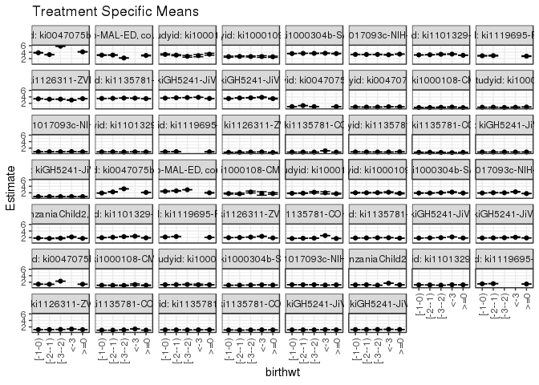

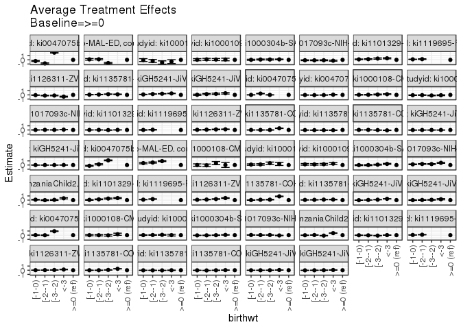

## Results Table

### Parameter: TSM

| agecat | studyid | country | intervention_level | baseline_level | estimate | ci_lower | ci_upper |
| --- | --- | --- | --- | --- | --- | --- | --- |
| 0-3 months | ki0047075b-MAL-ED | BRAZIL | >=0 | NA | 4.1198736 | 4.0291535 | 4.2105937 |
| 0-3 months | ki0047075b-MAL-ED | BRAZIL | [-3–2) | NA | 5.8427051 | 5.7835005 | 5.9019097 |
| 0-3 months | ki0047075b-MAL-ED | BRAZIL | [-2–1) | NA | 3.2626815 | 3.1685724 | 3.3567907 |
| 0-3 months | ki0047075b-MAL-ED | BRAZIL | [-1-0) | NA | 3.8319843 | 3.7313327 | 3.9326358 |
| 0-3 months | ki0047075b-MAL-ED | TANZANIA, UNITED REPUBLIC OF | >=0 | NA | 2.9961676 | 2.8695763 | 3.1227589 |
| 0-3 months | ki0047075b-MAL-ED | TANZANIA, UNITED REPUBLIC OF | [-3–2) | NA | 2.2209161 | 2.1679611 | 2.2738711 |
| 0-3 months | ki0047075b-MAL-ED | TANZANIA, UNITED REPUBLIC OF | [-2–1) | NA | 3.1271106 | 3.0395784 | 3.2146428 |
| 0-3 months | ki0047075b-MAL-ED | TANZANIA, UNITED REPUBLIC OF | [-1-0) | NA | 3.1090427 | 2.9855531 | 3.2325322 |
| 0-3 months | ki1000108-IRC | INDIA | >=0 | NA | 3.3791541 | 3.0827365 | 3.6755716 |
| 0-3 months | ki1000108-IRC | INDIA | <-3 | NA | 2.9483327 | 2.5943012 | 3.3023642 |
| 0-3 months | ki1000108-IRC | INDIA | [-3–2) | NA | 2.7361964 | 2.4712565 | 3.0011364 |
| 0-3 months | ki1000108-IRC | INDIA | [-2–1) | NA | 3.1043324 | 2.9249187 | 3.2837460 |
| 0-3 months | ki1000108-IRC | INDIA | [-1-0) | NA | 3.3158859 | 3.1395362 | 3.4922357 |
| 0-3 months | ki1000109-EE | PAKISTAN | >=0 | NA | 2.6010076 | 2.4158626 | 2.7861525 |
| 0-3 months | ki1000109-EE | PAKISTAN | <-3 | NA | 2.6770219 | 2.4263836 | 2.9276601 |
| 0-3 months | ki1000109-EE | PAKISTAN | [-3–2) | NA | 2.6716909 | 2.5085460 | 2.8348358 |
| 0-3 months | ki1000109-EE | PAKISTAN | [-2–1) | NA | 2.7113148 | 2.5649596 | 2.8576700 |
| 0-3 months | ki1000109-EE | PAKISTAN | [-1-0) | NA | 2.6325956 | 2.4719645 | 2.7932266 |
| 0-3 months | ki1000304b-SAS-CompFeed | INDIA | >=0 | NA | 3.5750169 | 3.4677565 | 3.6822773 |
| 0-3 months | ki1000304b-SAS-CompFeed | INDIA | <-3 | NA | 3.6824308 | 3.5958623 | 3.7689994 |
| 0-3 months | ki1000304b-SAS-CompFeed | INDIA | [-3–2) | NA | 3.6486608 | 3.5724064 | 3.7249153 |
| 0-3 months | ki1000304b-SAS-CompFeed | INDIA | [-2–1) | NA | 3.6459733 | 3.6138464 | 3.6781002 |
| 0-3 months | ki1000304b-SAS-CompFeed | INDIA | [-1-0) | NA | 3.5787731 | 3.5249876 | 3.6325586 |
| 0-3 months | ki1017093c-NIH-Crypto | BANGLADESH | >=0 | NA | 3.4068070 | 3.3328541 | 3.4807600 |
| 0-3 months | ki1017093c-NIH-Crypto | BANGLADESH | <-3 | NA | 3.2051985 | 3.1121095 | 3.2982874 |
| 0-3 months | ki1017093c-NIH-Crypto | BANGLADESH | [-3–2) | NA | 3.3061020 | 3.2205159 | 3.3916882 |
| 0-3 months | ki1017093c-NIH-Crypto | BANGLADESH | [-2–1) | NA | 3.2932794 | 3.2349344 | 3.3516245 |
| 0-3 months | ki1017093c-NIH-Crypto | BANGLADESH | [-1-0) | NA | 3.3063586 | 3.2390713 | 3.3736459 |
| 0-3 months | ki1101329-Keneba | GAMBIA | >=0 | NA | 3.0560292 | 2.9821673 | 3.1298910 |
| 0-3 months | ki1101329-Keneba | GAMBIA | <-3 | NA | 3.4187043 | 3.3206238 | 3.5167849 |

[output cut: 226 more lines]

### Parameter: E(Y)

[output not shown]

### Parameter: ATE

| agecat | studyid | country | intervention_level | baseline_level | estimate | ci_lower | ci_upper |
| --- | --- | --- | --- | --- | --- | --- | --- |
| 0-3 months | ki0047075b-MAL-ED | BRAZIL | >=0 | >=0 | 0.0000000 | 0.0000000 | 0.0000000 |
| 0-3 months | ki0047075b-MAL-ED | BRAZIL | [-3–2) | >=0 | 1.7228315 | 1.6207800 | 1.8248831 |
| 0-3 months | ki0047075b-MAL-ED | BRAZIL | [-2–1) | >=0 | -0.8571920 | -0.9804677 | -0.7339164 |
| 0-3 months | ki0047075b-MAL-ED | BRAZIL | [-1-0) | >=0 | -0.2878893 | -0.4085444 | -0.1672342 |
| 0-3 months | ki0047075b-MAL-ED | TANZANIA, UNITED REPUBLIC OF | >=0 | >=0 | 0.0000000 | 0.0000000 | 0.0000000 |
| 0-3 months | ki0047075b-MAL-ED | TANZANIA, UNITED REPUBLIC OF | [-3–2) | >=0 | -0.7752515 | -0.9181417 | -0.6323613 |
| 0-3 months | ki0047075b-MAL-ED | TANZANIA, UNITED REPUBLIC OF | [-2–1) | >=0 | 0.1309431 | -0.0140073 | 0.2758934 |
| 0-3 months | ki0047075b-MAL-ED | TANZANIA, UNITED REPUBLIC OF | [-1-0) | >=0 | 0.1128751 | -0.0875515 | 0.3133017 |
| 0-3 months | ki1000108-IRC | INDIA | >=0 | >=0 | 0.0000000 | 0.0000000 | 0.0000000 |
| 0-3 months | ki1000108-IRC | INDIA | <-3 | >=0 | -0.4308213 | -0.8912897 | 0.0296471 |
| 0-3 months | ki1000108-IRC | INDIA | [-3–2) | >=0 | -0.6429576 | -1.0388857 | -0.2470295 |
| 0-3 months | ki1000108-IRC | INDIA | [-2–1) | >=0 | -0.2748217 | -0.6196177 | 0.0699743 |
| 0-3 months | ki1000108-IRC | INDIA | [-1-0) | >=0 | -0.0632681 | -0.4071169 | 0.2805806 |
| 0-3 months | ki1000109-EE | PAKISTAN | >=0 | >=0 | 0.0000000 | 0.0000000 | 0.0000000 |
| 0-3 months | ki1000109-EE | PAKISTAN | <-3 | >=0 | 0.0760143 | -0.2353674 | 0.3873959 |
| 0-3 months | ki1000109-EE | PAKISTAN | [-3–2) | >=0 | 0.0706833 | -0.1762615 | 0.3176281 |
| 0-3 months | ki1000109-EE | PAKISTAN | [-2–1) | >=0 | 0.1103073 | -0.1254526 | 0.3460671 |
| 0-3 months | ki1000109-EE | PAKISTAN | [-1-0) | >=0 | 0.0315880 | -0.2137377 | 0.2769137 |
| 0-3 months | ki1000304b-SAS-CompFeed | INDIA | >=0 | >=0 | 0.0000000 | 0.0000000 | 0.0000000 |
| 0-3 months | ki1000304b-SAS-CompFeed | INDIA | <-3 | >=0 | 0.1074139 | 0.0244593 | 0.1903686 |
| 0-3 months | ki1000304b-SAS-CompFeed | INDIA | [-3–2) | >=0 | 0.0736439 | -0.0569815 | 0.2042693 |
| 0-3 months | ki1000304b-SAS-CompFeed | INDIA | [-2–1) | >=0 | 0.0709564 | -0.0472282 | 0.1891409 |
| 0-3 months | ki1000304b-SAS-CompFeed | INDIA | [-1-0) | >=0 | 0.0037562 | -0.1333079 | 0.1408202 |
| 0-3 months | ki1017093c-NIH-Crypto | BANGLADESH | >=0 | >=0 | 0.0000000 | 0.0000000 | 0.0000000 |
| 0-3 months | ki1017093c-NIH-Crypto | BANGLADESH | <-3 | >=0 | -0.2016086 | -0.3204778 | -0.0827394 |
| 0-3 months | ki1017093c-NIH-Crypto | BANGLADESH | [-3–2) | >=0 | -0.1007050 | -0.2137788 | 0.0123688 |
| 0-3 months | ki1017093c-NIH-Crypto | BANGLADESH | [-2–1) | >=0 | -0.1135276 | -0.2077538 | -0.0193014 |
| 0-3 months | ki1017093c-NIH-Crypto | BANGLADESH | [-1-0) | >=0 | -0.1004485 | -0.2004974 | -0.0003996 |
| 0-3 months | ki1101329-Keneba | GAMBIA | >=0 | >=0 | 0.0000000 | 0.0000000 | 0.0000000 |
| 0-3 months | ki1101329-Keneba | GAMBIA | <-3 | >=0 | 0.3626751 | 0.2412244 | 0.4841258 |

[output cut: 226 more lines]